# Checkpoint 6

Katya Kelly & Katja McKiernan

December 7, 2017

## Progress

Since the last checkpoint, we have set up a Bayesian Poisson regression model to estimate the rate of large earthquakes per year. We have also set up most of a model to predict magnitude based on the categorical variable region that we created and added to our data set.  
Katja worked on creating and adding the categorical region variable, while Katya worked on adding the years without any large quakes to our data set. We both worked equally on the models and rjags simulations.  
Our next steps involve cleaning up models and code and using our estimated rate of large earthquakes $\lambda$ to predict the time until the next large quake. We may also want to investigate the year 1957, which had 8 earthquakes over the magnitude of 7, the most by far of any year.

/

```r
cleanQuakes = read.csv("cleanQuakes.csv")

library(dplyr)
cleanQuakes1 <- cleanQuakes %>%
  select(-c(X.1))
```

```r
library(stringr)
library(lubridate)
#Creating year, month, and day columns and adding to cleanQuakes1
Year_ <- year(cleanQuakes1$time)
Month_ <- month(cleanQuakes1$time)
Day_ <- day(cleanQuakes1$time)
cleanQuakes1 <- cbind(cleanQuakes1, Year_)
cleanQuakes1 <- cbind(cleanQuakes1, Month_)
cleanQuakes1 <- cbind(cleanQuakes1, Day_)

cleanQuakes1$time <- substring(cleanQuakes1$time, 1, 19)
time_of_Quake <- str_sub(cleanQuakes1$time, -8,-1)
cleanQuakes1 <- cbind(cleanQuakes1, time_of_Quake)

cleanQuakesFin <- cleanQuakes1 %>%
  select(-c(time))
```

```r
quakesAbove7 <- filter(cleanQuakesFin, mag >= 7)
quakesSince1950 <- filter(cleanQuakesFin, Year_ >= 1950)
quakesAbove7Since1950 <- filter(cleanQuakesFin, Year_ >=1950, mag >= 7)
```

```r
#Creating regions Hawaii, Alaska, Canada, Mexico, US for each quake

cleanQuakesFin$region = cleanQuakesFin$place
cleanQuakesFin$region = as.character(cleanQuakesFin$region)

createRegion <- function(dataset){
  dataset <- within(dataset, region[grepl("Hawaii", dataset$region)]<-"Hawaii")
  dataset <- within(dataset, region[grepl("Alaska", dataset$region)]<- "Alaska")
  dataset <- within(dataset, region[grepl("Canada", dataset$region)]<- "Canada")
  dataset <- within(dataset, region[grepl("MX", dataset$region)]<- "Mexico")
  dataset <- within(dataset, region[grepl("Mexico", dataset$region)]<- "Mexico")
  dataset <- within(dataset, region[grepl("California", dataset$region)]<- "US")
  dataset <- within(dataset, region[grepl("Guatemala", dataset$region)]<- "Mexico")
  dataset <- within(dataset, region[grepl("El Salvador", dataset$region)]<- "Mexico")
  dataset <- within(dataset, region[grepl("Venezuela", dataset$region)]<- "Mexico")
  dataset <- within(dataset, region[grepl("CA", dataset$region)]<- "US")
  dataset <- within(dataset, region[grepl("Nicaragua", dataset$region)]<- "Mexico")
  dataset <- within(dataset, region[grepl("Honduras", dataset$region)]<- "Mexico")
  dataset <- within(dataset, region[grepl("Oregon", dataset$region)]<- "US")
  dataset <- within(dataset, region[grepl("Washington", dataset$region)]<- "US")
  dataset <- within(dataset, region[grepl("Russia", dataset$region)]<- "Alaska")
  dataset <- within(dataset, region[grepl("Revilla", dataset$region)]<- "Mexico")
  dataset <- within(dataset, region[grepl("Nevada", dataset$region)]<- "US")
  dataset <- within(dataset, region[grepl("NV", dataset$region)]<- "US")
  dataset <- within(dataset, region[grepl("Wyoming", dataset$region)]<- "US")
  dataset <- within(dataset, region[grepl("Montana", dataset$region)]<- "US")
  dataset <- within(dataset, region[grepl("Aleutian", dataset$region)]<- "Alaska")
  dataset <- within(dataset, region[grepl("Ocean", dataset$region)]<- "Mexico")
  dataset <- within(dataset, region[grepl("Bristol", dataset$region)]<- "Alaska")
  dataset <- within(dataset, region[grepl("Bering", dataset$region)]<- "Alaska")
}

cleanQuakesFin <- createRegion(cleanQuakesFin)
```

### Question: Can we predict magnitude by region (categorical)?

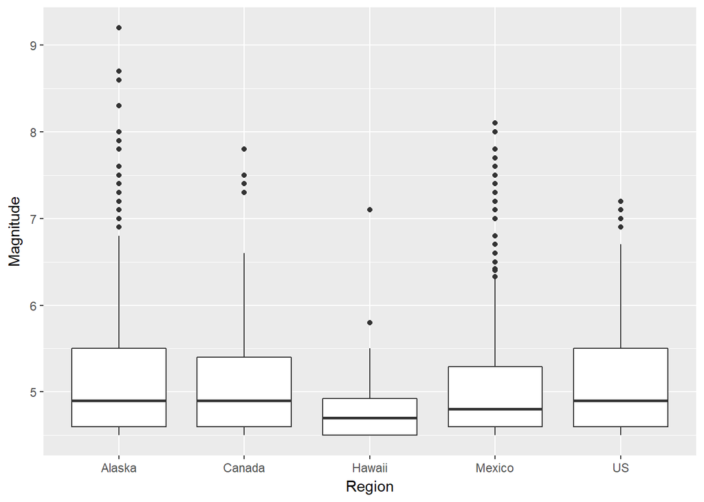

```r
# Adding region indicator variables to data set
regionClean <- cleanQuakesFin

cat_regionMatrix <- model.matrix(id ~ region, regionClean)
colnames(cat_regionMatrix)[1] <- c("Intercept")

regionClean <- cbind(regionClean,cat_regionMatrix)

regionClean <- regionClean %>%
  select(-c((Intercept)))

# Plot magnitude by region
library(ggplot2)
ggplot(data=regionClean, aes(x=region, y=mag)) + geom_boxplot() + xlab("Region") + ylab("Magnitude")
```

Based on these boxplots, the relationship between magnitude and region seems not incredibly significant, but we will try a model anyway. It appears that the variance is somewhat different among these regions, but the medians hover around the same value of just under 5.
Notation: $M_i$ - the magnitude of earthquake $i$
$rCan_i$ - indicator of whether or not earthquake $i$ was in the Canada region
$rMex_i$ - indicator of whether or not earthquake $i$ was in the Mexico region
$rHI_i$ - indicator of whether or not earthquake $i$ was in the Hawaii region
$rUS_i$ - indicator of whether or not earthquake $i$ was in the US region
Model:
$$M_i|\beta_0, \beta_1, \beta_2, \beta_3, \beta_4, \tau_0, \tau_1, \tau_2, \tau_3, \tau_4 \sim N(\beta_0 + \beta_1*rCan_i + \beta_2*rMex_i + \beta_3*rHI_i + \beta_3*rUS_i, (tau_0 + tau_1*rCan_i + tau_2*rMex_i + tau_3*rHI_i + tau_4*rUS_i)^{-1}$$
$$\beta_k, \tau_k \sim N(0, 100^2)$$

```r
# Rjags for magnitude by region (categorical)

library(rjags)
mag_region_model <- "model{
  #Data
  for (i in 1:length(M)) {
    #Note: dnorm in rjags takes the precision, not st. dev.
    M[i] ~ dnorm(beta0 + beta1*rCan[i] + beta2*rMex[i] + beta3*rHI[i] + beta4*rUS[i], tau0 + tau1*rCan[i] + tau2*rMex[i] + tau3*rHI[i] + tau4*rUS[i])
  }

  #Priors - vague, assume no knowledge of relationship between region and magnitude or variance among regions

  beta0 ~ dnorm(0, 1/100^2)
  beta1 ~ dnorm(0, 1/100^2)
  beta2 ~ dnorm(0, 1/100^2)
  beta3 ~ dnorm(0, 1/100^2)
  beta4 ~ dnorm(0, 1/100^2)

  tau0 ~ dnorm(10, 1/100^2)
  tau1 ~ dnorm(10, 1/100^2)
  tau2 ~ dnorm(10, 1/100^2)
  tau3 ~ dnorm(10, 1/100^2)
  tau4 ~ dnorm(10, 1/100^2)

}"

#set up an algorithm to simulate the posterior by
#combining the model (nfl_model) and data (sports)
#set the random number seed
mag_region_jags <- jags.model(textConnection(mag_region_model),
                        data = list(M=regionClean$mag, rCan=regionClean$regionCanada, rMex=regionClean$regionMexico, rHI = regionClean$regionHawaii, rUS = regionClean$regionUS),
                        inits = list(.RNG.name = "base::Wichmann-Hill", .RNG.seed = 1989))
#simulate a sample from the posterior
mag_region_sim <- coda.samples(mag_region_jags,
                        variable.names = c("tau0", "tau1", "tau2", "tau3", "tau4", "beta0", "beta1", "beta2", "beta3", "beta4"), n.iter=10000)

#store the samples in a data frame:
mag_region_samples <- data.frame(steps=c(1:10000), mag_region_sim[[1]])
head(mag_region_samples)
```

```
##   steps    beta0        beta1       beta2      beta3       beta4     tau0
## 1     1 5.158445  0.081350349 -0.08163541 -0.4731485  0.09022009 2.287272
## 2     2 5.146888 -0.064937393 -0.06576449 -0.3294235  0.14904026 2.293719
## 3     3 5.141785  0.019728527 -0.05569471 -0.2416923  0.05858177 2.241509
## 4     4 5.132545 -0.001470328 -0.07602674 -0.2745948  0.12278894 2.217864
## 5     5 5.165826 -0.037696156 -0.08148765 -0.3572315 -0.04452624 2.424795
## 6     6 5.143555 -0.060148612 -0.07637419 -0.3374464  0.02564193 2.393397
##           tau1       tau2        tau3        tau4
## 1 -0.385934910 -0.1178113 -0.05134143 -0.52967882
## 2  0.031388647 -0.1544806  1.14404658 -0.81915309
## 3 -0.017179170 -0.2443586  0.76458962  0.08784905
## 4 -0.002854451 -0.4354560 -0.20071051 -0.67213739
## 5 -0.111599665 -0.3528154 -0.08803352 -0.74520383
## 6 -0.092403677 -0.5503250  0.86856739 -0.49314910
```

```r
summary(mag_region_sim)
```

```
##
## Iterations = 1001:11000
## Thinning interval = 1
## Number of chains = 1
## Sample size per chain = 10000
##
## 1. Empirical mean and standard deviation for each variable,
##    plus standard error of the mean:
##
##            Mean      SD  Naive SE Time-series SE
## beta0  5.136782 0.01299 0.0001299      0.0001594
## beta1 -0.006343 0.06144 0.0006144      0.0006503
## beta2 -0.054444 0.03606 0.0003606      0.0004086
## beta3 -0.237159 0.12076 0.0012076      0.0012076
## beta4  0.060827 0.07921 0.0007921      0.0008274
## tau0   2.321682 0.06343 0.0006343      0.0011275
## tau1  -0.223058 0.26193 0.0026193      0.0036362
## tau2  -0.497096 0.13412 0.0013412      0.0022113
## tau3   0.837608 0.89542 0.0089542      0.0123956
## tau4  -0.515418 0.26541 0.0026541      0.0038217
##
## 2. Quantiles for each variable:
##
##           2.5%       25%       50%      75%      97.5%
## beta0  5.11135  5.128066  5.136774  5.14549  5.1623245
## beta1 -0.12731 -0.047131 -0.005792  0.03402  0.1154252
## beta2 -0.12471 -0.079003 -0.054730 -0.02982  0.0160367
## beta3 -0.47722 -0.318208 -0.236424 -0.15730 -0.0001032
## beta4 -0.09591  0.007346  0.061364  0.11362  0.2151794
## tau0   2.20012  2.279196  2.320985  2.36286  2.4497673
## tau1  -0.70477 -0.408011 -0.229978 -0.05235  0.3184866
## tau2  -0.75088 -0.590225 -0.499295 -0.40636 -0.2325247
## tau3  -0.64144  0.194148  0.743316  1.38150  2.8786974
## tau4  -1.00491 -0.703424 -0.525227 -0.34317  0.0291699
```

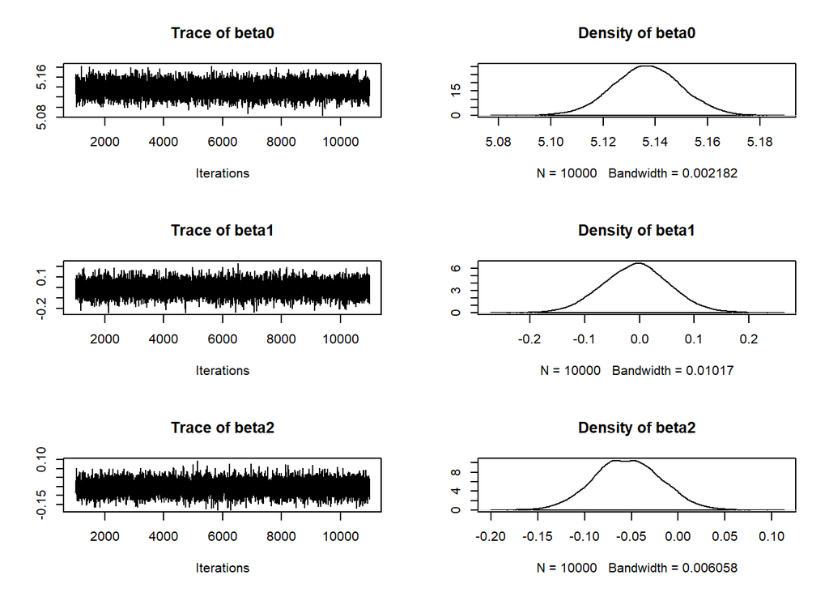

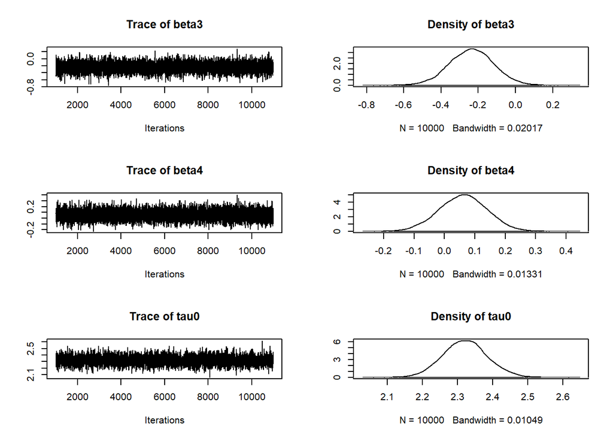

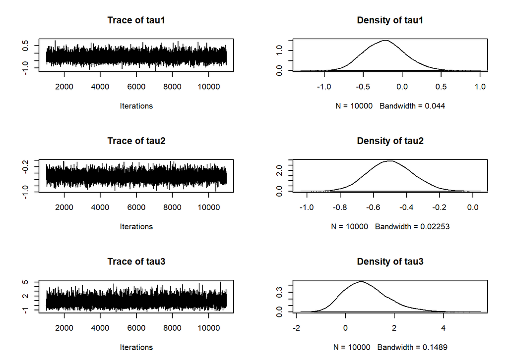

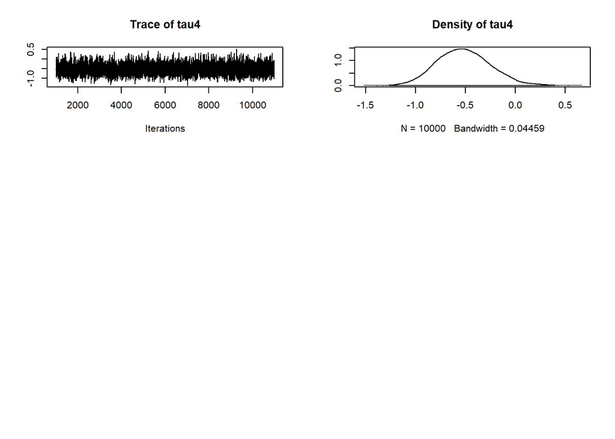

```r
plot(mag_region_sim)
```

With Alaska as our reference region, we believe this model is telling us that Hawaii, Mexico, and Canada tend to have earthquakes with slightly smaller magnitude on average, while the continental US tends to have slightly larger earthquakes. This might be surprising at first because Alaska has the most large earthquakes (above magnitude 7), but it also has many more small earthquakes, bringing the total percentage of large earthquakes down.

```r
# Cutting longitude into 9 categorical ranges of width 20 degrees - The (0, 1] interval is for years with no large earthquakes
longCategories <- cut(quakesAbove7$longitude, c(-180, -160, -140, -120, -100, -80, 0, 1, 160, 180))
head(longCategories)
```

```
## [1] (-160,-140] (-100,-80]  (-120,-100] (-120,-100] (-120,-100] (-120,-100]
## 9 Levels: (-180,-160] (-160,-140] (-140,-120] (-120,-100] ... (160,180]
```

```r
quakesAbove7$LongCat = longCategories

# Adding years with 0 large earthquakes into data so models are more accurate
missingYears7 <- c(1900:2016)[!(c(1900:2016) %in% quakesAbove7$Year_)]
missingYearsCount7 <- rep(0, length(missingYears7))

quakes116Above7 <- data.frame(Year_ = missingYears7, X = rep(NA, length(missingYears7)), latitude = rep(NA, length(missingYears7)), longitude = rep(NA, length(missingYears7)), depth = rep(NA, length(missingYears7)), mag = rep(0, length(missingYears7)), magType = rep(NA, length(missingYears7)), id = rep(NA, length(missingYears7)), place = rep(NA, length(missingYears7)), type = rep(NA, length(missingYears7)), locationSource = rep(NA, length(missingYears7)), magSource = rep(NA, length(missingYears7)), Month_ = rep(NA, length(missingYears7)), Day_ = rep(NA, length(missingYears7)), time_of_Quake = rep(NA, length(missingYears7)), LongCat = rep("(0,1]", length(missingYears7)))

quakes116Above7Fin <-rbind(quakes116Above7, quakesAbove7)


# Grouping earthquakes by year and longitude category
groupedQuakes116 <- quakes116Above7Fin %>%
  group_by(Year_, LongCat) %>%
  summarise(medianMag = median(mag), count = n())

# Resetting the count to 0 for years without large earthquakes
for(i in 1:nrow(groupedQuakes116)){
  if (groupedQuakes116$Year_[i] %in% missingYears7){
  groupedQuakes116$count[i] = 0
  }
}
```

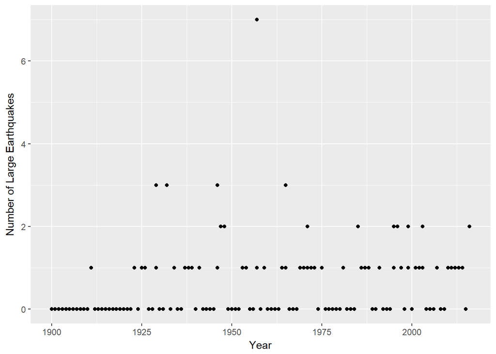

```r
# Plot number of large earthquakes by year
library(ggplot2)
ggplot(data=groupedQuakes116, aes(x=Year_, y=count)) + geom_point() + xlab("Year") + ylab("Number of Large Earthquakes")
```

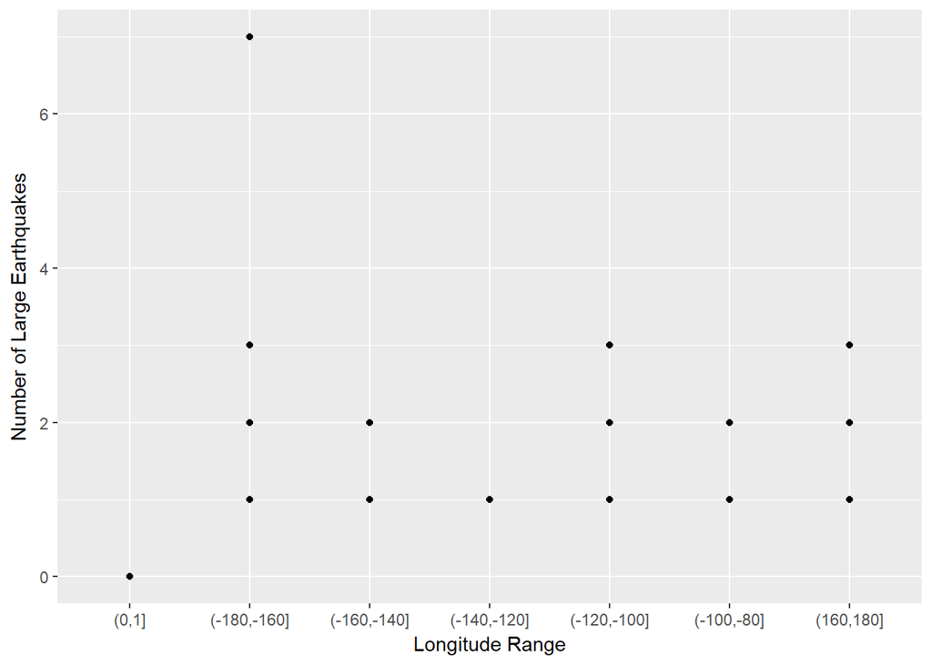

```r
# Plot number of large earthquakes by longitude group
ggplot(data=groupedQuakes116, aes(x=LongCat, y=count)) + geom_point() + xlab("Longitude Range") +
  ylab("Number of Large Earthquakes")
```

### Question - Can we use our data to estimate the rate of earthquakes per year?

$N_{i}$ - the number of large earthquakes in row $i$ (rows sorted by year & longitude range)  
$\lambda_{i}$ - the rate of large earthquakes per longitude range per year in row $i$  
$lon_{i}$ - the longitude range of the earthquakes that happened in row $i$  
$year_{i}$ - the year in which the earthquakes in row $i$ occurred  
Models:

$$N_{i} \sim Pois(\lambda_{i})$$
$$\log(\lambda_{i}) = \beta_0 + \beta_1*lon_i + \beta_2*year_i$$
$$\beta_k \sim N(0, 100^2)$$

```r
# Rjags for Poisson regression - estimating rate of earthquakes per longitude range per year, lambda

pois_rate_model <- "model{
  #Data
  for (i in 1:length(numQuakes)) {
    #Note: dnorm in rjags takes the precision, not st. dev.
    numQuakes[i] ~ dpois(lambda[i])
    log(lambda[i]) = beta0 + beta1[lon[i]] + beta2*year[i]
  }

  #Priors - very vague, we assume we know nothing about the rate of earthquakes or how this rate
  # is affected by our chosen variables

  beta0 ~ dnorm(0, 1/100^2)
  beta1[1] <- 0
  for (i in 2:9) {
    beta1[i] ~ dnorm(0, 1/100^2)
  }
  beta2 ~ dnorm(0, 1/100^2)

}"

#set up an algorithm to simulate the posterior by
#combining the model (nfl_model) and data (sports)
#set the random number seed
pois_rate_jags <- jags.model(textConnection(pois_rate_model),
                        data = list(numQuakes = groupedQuakes116$count, lon = groupedQuakes116$LongCat, year = groupedQuakes116$Year_),
                        inits = list(.RNG.name = "base::Wichmann-Hill", .RNG.seed = 1989))
#simulate a sample from the posterior
pois_rate_sim <- coda.samples(pois_rate_jags,
                        variable.names = c("beta0", "beta1", "beta2"), n.iter=10000)

#store the samples in a data frame:
pois_rate_samples <- data.frame(steps=c(1:10000), pois_rate_sim[[1]])
head(pois_rate_samples)
```

```
##   steps     beta0 beta1.1. beta1.2. beta1.3. beta1.4. beta1.5. beta1.6.
## 1     1 -3.224450        0 8.791348 8.387228 7.900600 8.290799 8.395773
## 2     2 -3.054414        0 8.967282 8.176770 7.965376 8.248939 8.276560
## 3     3 -3.055262        0 8.328175 7.949670 8.100799 7.918168 8.464439
## 4     4 -2.977232        0 8.454729 8.107650 7.946576 8.181090 8.629446
## 5     5 -2.894231        0 8.506833 7.998933 7.915542 8.040652 8.936117
## 6     6 -3.008785        0 8.586706 8.099966 7.833669 8.262599 7.953311
##      beta1.7.   beta1.8. beta1.9.        beta2
## 1 -109.173153  -15.29859 8.651464 -0.002535660
## 2   -6.350522   20.21151 8.446325 -0.002527917
## 3   -4.294035 -116.69933 8.126780 -0.002462018
## 4  -44.976779  134.68935 7.917585 -0.002577625
## 5   83.245300  -15.58552 7.641341 -0.002547806
## 6 -151.773260   30.68597 7.747294 -0.002547726
```

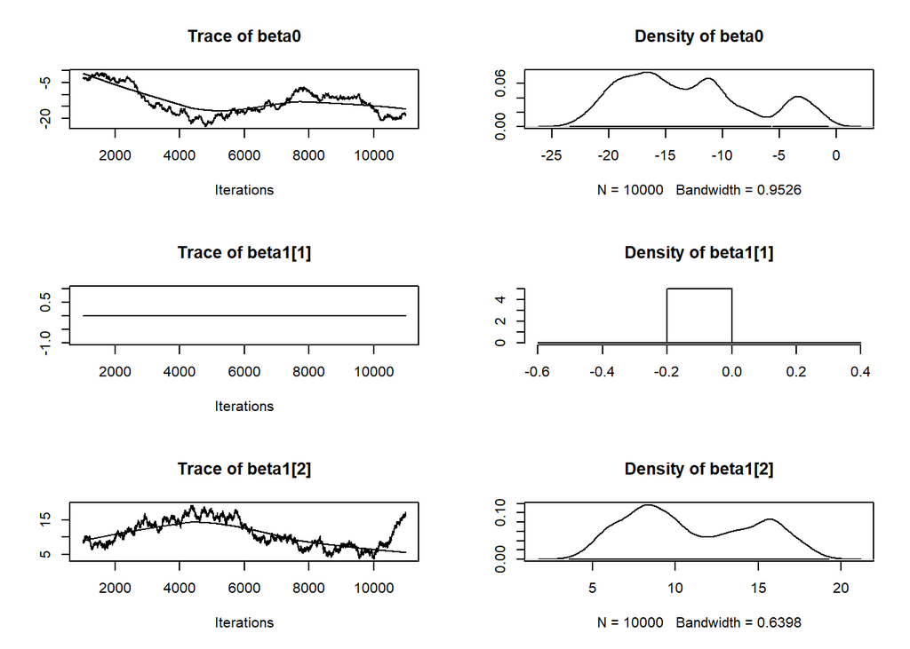

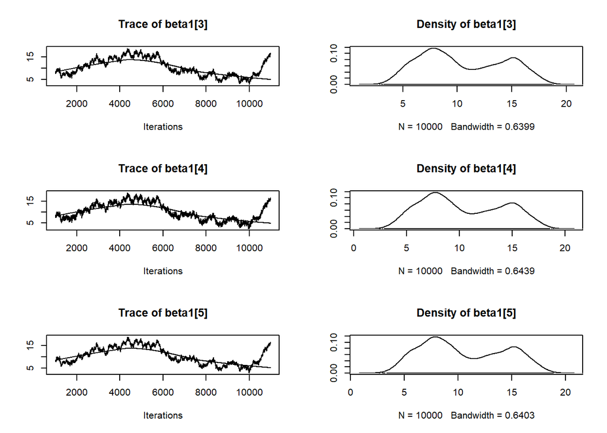

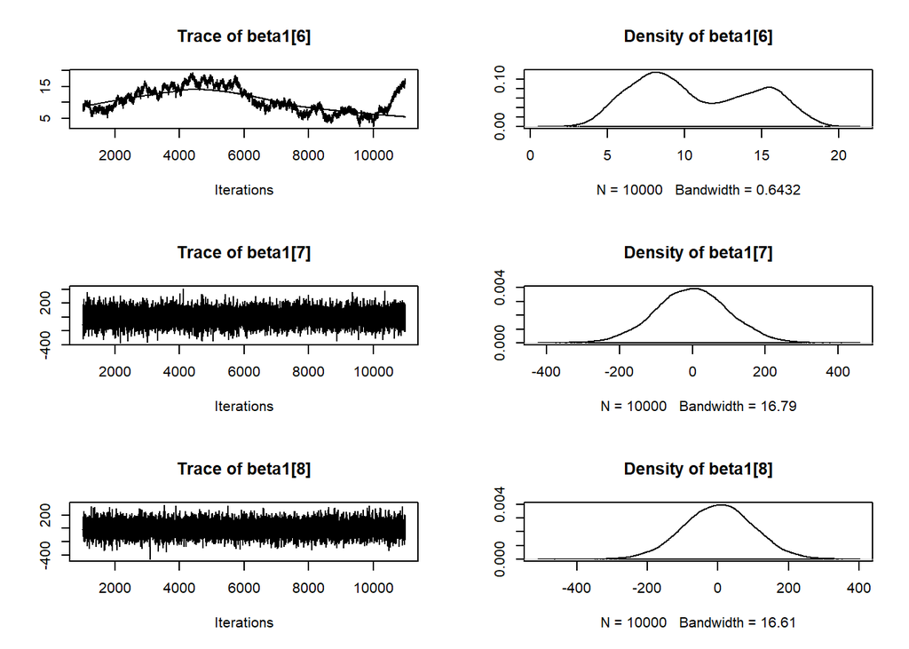

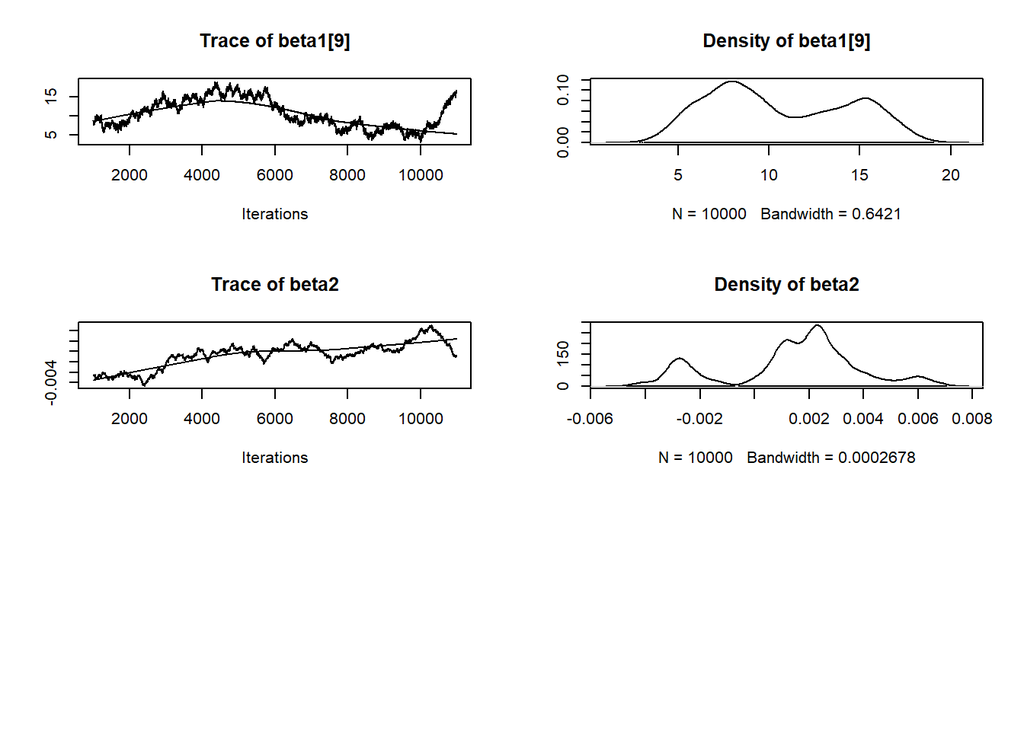

```r
plot(pois_rate_sim)
```

```r
summary(pois_rate_sim)
```

```
##
## Iterations = 1001:11000
## Thinning interval = 1
## Number of chains = 1
## Sample size per chain = 10000
##
## 1. Empirical mean and standard deviation for each variable,
##    plus standard error of the mean:
##
##                Mean        SD  Naive SE Time-series SE
## beta0    -13.140459 5.670e+00 5.670e-02       3.696973
## beta1[1]   0.000000 0.000e+00 0.000e+00       0.000000
## beta1[2]  11.008439 3.809e+00 3.809e-02       1.895262
## beta1[3]  10.467876 3.809e+00 3.809e-02       1.921494
## beta1[4]  10.292703 3.833e+00 3.833e-02       1.956362
## beta1[5]  10.510936 3.811e+00 3.811e-02       1.941148
## beta1[6]  10.775942 3.828e+00 3.828e-02       1.955973
## beta1[7]  -0.929537 1.005e+02 1.005e+00       1.005473
## beta1[8]   1.541189 9.889e+01 9.889e-01       0.988926
## beta1[9]  10.591927 3.822e+00 3.822e-02       1.991296
## beta2      0.001404 2.445e-03 2.445e-05       0.001546
##
## 2. Quantiles for each variable:
##
##                2.5%        25%        50%        75%      97.5%
## beta0    -2.159e+01 -1.766e+01 -14.154831 -10.004340  -1.768214
## beta1[1]  0.000e+00  0.000e+00   0.000000   0.000000   0.000000
## beta1[2]  5.168e+00  7.886e+00  10.112119  14.565433  17.686029
## beta1[3]  4.580e+00  7.341e+00   9.582180  14.051811  17.139822
## beta1[4]  4.326e+00  7.188e+00   9.431427  13.908325  17.078295
## beta1[5]  4.655e+00  7.396e+00   9.599855  14.081799  17.186432
## beta1[6]  4.818e+00  7.641e+00   9.924859  14.302482  17.513523
## beta1[7] -1.989e+02 -6.770e+01  -0.637327  66.190137 194.906091
## beta1[8] -1.958e+02 -6.537e+01   2.182395  67.433602 196.372442
## beta1[9]  4.687e+00  7.472e+00   9.694323  14.155334  17.282373
## beta2    -3.306e-03  6.051e-04   0.001856   0.002741   0.006085
```

Still working on interpretation of this model